# PFAB algorithm

Matt Moores

2018-06-06

A new version 0.5-0 of my `R` package **bayesImageS** is [now available on CRAN](http://dirk.eddelbuettel.com/cranberries/2018/01/26#bayesImageS_0.5-0). To accompany it is a revision to my paper with Kerrie and Tony, “Scalable Bayesian inference for the inverse temperature of a hidden Potts model.” ([Moores, Pettitt & Mengersen, arXiv:1503.08066v2](http://arxiv.org/abs/1503.08066)). This paper introduces the parametric functional approximate Bayesian (PFAB) algorithm *(the ‘p’ is silent…)*, which is a form of Bayesian indirect likelihood (BIL).

PFAB splits computation into 3 stages:

1. Simulation for fixed $\beta$ using [Swendsen-Wang](https://mooresm.github.io/bayesImageS/articles/swNoData.html)
2. Fitting a parametric surrogate model using [Stan](http://mc-stan.org)
3. Approximate posterior inference using Metropolis-within-Gibbs

# Stage 1

For **Stage 1**, I used 2000 iterations of SW for each of 72 values of $\beta$, but this is really overkill for most applications. I chose 72 values because I happened to have a 36-core, hyperthreaded CPU available. Here I’ll just be running everything on my laptop (an *i*7 CPU with 4 hyperthreaded cores), so 28 values should be plenty. The idea is to have higher density closer to the critical temperature, where the variance (and hence the gradient of the score function) is greatest

For our precomputation step, we need to know the image dimensions $n$ and the number of labels $k$ that we will use for pixel classification. We’ll be using the [Lake of Menteith](https://en.wikipedia.org/wiki/Lake_of_Menteith) dataset from [Bayesian Essentials with R](http://www.springer.com/gb/book/9781461486862) (Marin & Robert, 2014):

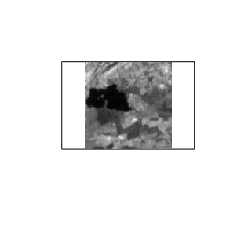

Lake of Menteith, Scotland

```r
library(bayess)
data("Menteith")
iter <- 800
burn <- iter/4 + 1
n <- prod(dim(Menteith))
k <- 6
image(as.matrix(Menteith),
      asp=1,xaxt='n',yaxt='n',col=gray(0:255/255))
```

```r
library(bayesImageS)
bcrit <- log(1 + sqrt(k))
beta <- sort(c(seq(0,1,by=0.1),seq(1.05,1.15,by=0.05),bcrit-0.05,bcrit-0.02,bcrit+0.02,
            seq(1.3,1.4,by=0.05),seq(1.5,2,by=0.1),2.5,3))
mask <- matrix(1, nrow=sqrt(n), ncol=sqrt(n))
neigh <- getNeighbors(mask, c(2,2,0,0))
block <- getBlocks(mask, 2)
edges <- getEdges(mask, c(2,2,0,0))
maxS <- nrow(edges)
E0 <- maxS/k
V0 <- maxS*(1/k)*(1 - 1/k)
```

Embarrasingly parallel, using all available CPU cores:

```r
library(doParallel)
cores <- min(detectCores(), length(beta))
print(paste("Parallel computation using",cores,"CPU cores:",
            iter,"iterations for",length(beta),"values of beta."))
cl <- makeCluster(cores)
print(cl)
clusterSetRNGStream(cl)
registerDoParallel(cl)
```

Simulate from the prior to verify the critical value of $\beta$:

```r
tm <- system.time(matu <- foreach(i=1:length(beta),
          .packages=c("bayesImageS"), .combine='cbind') %dopar% {
  res <- swNoData(beta[i],k,neigh,block,iter)
  res$sum
})
stopCluster(cl)
```

```
##    user  system elapsed
##   0.185   0.151  19.384
```

This shows the piecewise linear approximation that we used in our first paper ([Moores et al., STCO 2015](https://doi.org/10.1007/s11222-014-9525-6)):

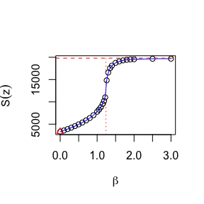

Piecewise linear approximation

```r
plot(x=beta, y=colMeans(simSW$matu),main="",
     xlab=expression(beta),ylab=expression(S(z)))
lrcst=approxfun(beta,colMeans(simSW$matu))
curve(lrcst,0,max(beta),add=T,col="blue")
abline(v=bcrit,col="red",lty=3)
abline(h=maxS,col=2,lty=2)
points(0,E0,col=2,pch=2)
```

# Stage 2

Instead, for **Stage 2** we will use Stan to fit a parametric integral curve:

```stan
functions {
  vector ft(vector t, real tC, real e0, real ecrit, real v0, real vmaxLo, real vmaxHi, real phi1, real phi2) {
    vector[num_elements(t)] mu;
    real sqrtBcritPhi = sqrt(tC)*phi1;
    for (i in 1:num_elements(t)) {
      if (t[i] <= tC) {
        real sqrtBdiffPhi = sqrt(tC - t[i])*phi1;
        mu[i] = e0 + t[i]*v0 - ((2*(vmaxLo-v0))/(phi1^2))*((sqrtBcritPhi + 1)/exp(sqrtBcritPhi) - (sqrtBdiffPhi + 1)/exp(sqrtBdiffPhi));
      } else {
        real sqrtBdiff = sqrt(t[i] - tC);
        mu[i] = ecrit - ((2*vmaxHi)/phi2)*(sqrtBdiff/exp(phi2*sqrtBdiff) + (exp(-phi2*sqrtBdiff) - 1)/phi2);
      }
    }
    return mu;
  }

  vector dfdt(vector t, real tC, real v0, real vmaxLo, real vmaxHi, real r1, real r2) {
    vector[num_elements(t)] dmu;
    for (i in 1:num_elements(t)) {
      if (t[i] <= tC) {
        dmu[i] = v0 + (vmaxLo-v0)*exp(-r1*sqrt(tC - t[i]));
      } else {
        dmu[i] = vmaxHi*exp(-r2*sqrt(t[i] - tC));
      }
    }
    return dmu;
  }
}
data {
  int<lower = 1> M;
  int<lower = 1> N;
  real<lower = 1> maxY;
  real<lower = 1> Vlim;
  real<lower = 0> e0;
  real<lower = 0> v0;
  real tcrit;
  matrix<lower=0, upper=maxY>[M,N] y;
  vector[M] t;
}
parameters {
  real<lower = 0> a;
  real<lower = 0> b;
  real<lower = e0, upper=maxY> ecrit;
  real<lower = 0, upper=Vlim> vmaxLo;
  real<lower = 0, upper=Vlim> vmaxHi;
}
transformed parameters {
  vector[M] curr_mu;
  vector[M] curr_var;
  curr_mu = ft(t, tcrit, e0, ecrit, v0, vmaxLo, vmaxHi, a, b);
  curr_var = dfdt(t, tcrit, v0, vmaxLo, vmaxHi, a, b);
}
model {
  for (i in 1:M) {
    y[i,] ~ normal(curr_mu[i], sqrt(curr_var[i]));
  }
}
```

For comparison, see [a previous blog post](https://mattstats.wordpress.com/2017/06/12/fitting-nonlinear-functions-in-stan/) where I fitted a simple, logistic curve using Stan.

```r
library(rstan)
options(mc.cores = min(4, parallel::detectCores()))
dat <- list(M=length(beta), N=iter-burn+1, maxY=maxS, e0=E0, v0=V0,
            Vlim=2*maxS*log(maxS)/pi, tcrit=bcrit, y=t(simSW$matu[burn:iter,]), t=beta)
tm2 <- system.time(fit <- sampling(PFAB, data = dat, verbose=TRUE, iter=5000,
                            control = list(adapt_delta = 0.9, max_treedepth=20)))
```

```
##     user   system  elapsed
##    6.032    7.794 2140.408
```

```r
library(knitr)
kable(fitStan$summary, caption="95% highest posterior density intervals for pseudo-Voigt peaks",
      align = 'lrrrrrr', digits=3)
```

|  | mean | se_mean | sd | 2.5% | 97.5% | n_eff | Rhat |
| --- | --- | --- | --- | --- | --- | --- | --- |
| a | 4.546 | 0.000 | 0.005 | 4.535 | 4.556 | 3018.587 | 1.001 |
| b | 6.674 | 0.000 | 0.002 | 6.671 | 6.678 | 5517.964 | 1.000 |
| ecrit | 14210.513 | 0.042 | 2.996 | 14204.672 | 14216.457 | 5209.181 | 1.000 |
| vmaxLo | 58862.196 | 3.464 | 189.405 | 58489.777 | 59232.045 | 2989.964 | 1.001 |
| vmaxHi | 124677.101 | 0.599 | 30.050 | 124595.047 | 124706.591 | 2519.701 | 1.001 |

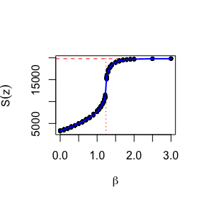

```r
ft <- function(t, tC, e0, ecrit, v0, vmax1, vmax2, phi1, phi2) {
  sqrtBcritPhi = sqrt(tC)*phi1
  fval <- numeric(length(t))
  for (i in 1:length(t)) {
    if (t[i] <= tC) {
      sqrtBdiffPhi = sqrt(tC - t[i])*phi1
      fval[i] <- e0 + t[i]*v0 - ((2*(vmax1-v0))/(phi1^2))*((sqrtBcritPhi + 1)/exp(sqrtBcritPhi) - (sqrtBdiffPhi + 1)/exp(sqrtBdiffPhi));
    } else {
      sqrtBdiff = sqrt(t[i] - tC)
      fval[i] <- ecrit - ((2*vmax2)/phi2)*(sqrtBdiff/exp(phi2*sqrtBdiff) + (exp(-phi2*sqrtBdiff) - 1)/phi2);
    }
  }
  return(fval)
}

plot(range(beta),range(simSW$matu),type='n',xlab=expression(beta),ylab=expression(S(z)))
idx <- burn+sample.int(iter-burn+1,size=20)
abline(v=bcrit,col="red",lty=3)
abline(h=maxS,col=2,lty=2)
points(rep(beta,each=20),simSW$matu[idx,],pch=20)
lines(beta, ft(beta, bcrit, E0, 14237, V0, 59019, 124668, 4.556, 6.691),
      col=4, lwd=2)
```

To really see how well this approximation fits the true model, we need to look at the residuals:

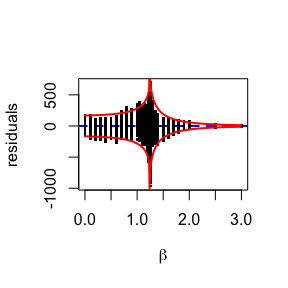

```r
residMx <- matrix(nrow=iter-burn+1, ncol=length(beta))
for (b in 1:length(beta)) {
  residMx[,b] <- simSW$matu[burn:iter,b] - ft(beta[b], bcrit, E0, 14237, V0, 59019, 124668, 4.556, 6.691)
}

dfdt <- function(t, tC, V0, Vmax1, Vmax2, r1, r2) {
  ifelse(t < tC,
         V0 + (Vmax1-V0)*exp(-r1*sqrt(tC - t)),
         Vmax2*exp(-r2*sqrt(t - tC)))
}

plot(range(beta),range(residMx),type='n',xlab=expression(beta),ylab="residuals")
abline(h=0,lty=2,col=4,lwd=2)
points(rep(beta,each=iter-burn+1),residMx,pch='.',cex=3)

x <- sort(c(seq(0,3,by=0.01),bcrit))
lines(x, 3*sqrt(dfdt(x, bcrit, V0, 59019, 124668, 4.556, 6.691)), col=2, lwd=2)
lines(x, -3*sqrt(dfdt(x, bcrit, V0, 59019, 124668, 4.556, 6.691)), col=2, lwd=2)
```

This shows that 28 values of $\beta$ were enough to obtain a high-quality fit between the true model and the surrogate. The location of $\beta_{crit}$ is slightly off, because $100 \times 100$ pixels isn’t quite enough for the asymptotics to kick in.

# Stage 3

Now that we have our surrogate model, we can proceed to the final stage, which is to perform image segmentation using `mcmcPotts`:

```r
mh <- list(algorithm="aux", bandwidth=0.02, Vmax1=59019,
           Vmax2=124668, E0=E0, Ecrit=14237, phi1=4.556,
           phi2=6.691, factor=1, bcrit=bcrit, V0=V0)
priors <- list()
priors$k <- k
priors$mu <- c(0, 50, 100, 150, 200, 250)
priors$mu.sd <- rep(10,k)
priors$sigma <- rep(20,k)
priors$sigma.nu <- rep(5, k)
priors$beta <- c(0,3)
iter <- 1e4
burn <- iter/2
y <- as.vector(as.matrix(Menteith))
print(date())
```

```
## [1] "Wed Jun  6 16:26:22 2018"
```

```r
tm3 <- system.time(resPFAB <-
             mcmcPotts(y,neigh,block,priors,mh,iter,burn))
```

```
## 10000 iterations of aux discarding the first 5000 as burn-in.
```

```r
print(tm3)
```

```
##    user  system elapsed
##  21.205   0.077  21.315
```

Now we compare with the approximate exchange algorithm:

```r
  mh <- list(algorithm="ex", bandwidth=0.02, auxiliary=200)
  tm4 <- system.time(resAEA <-
                       mcmcPotts(y,neigh,block,priors,mh,iter,burn))
  resAEA$time <- tm4[3]
```

```
##  elapsed
## 2306.565
```

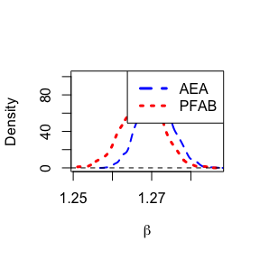

```r
densPFAB <- density(resPFAB$beta[burn:iter])
densAEA <- density(resAEA$beta[burn:iter])
plot(densAEA, col=4, lty=2, lwd=2, main="", xlab=expression(beta),
     xlim=range(resPFAB$beta[burn:iter],resAEA$beta[burn:iter]))
lines(densPFAB, col=2, lty=3, lwd=3)
abline(h=0,lty=2)
legend("topright",legend=c("AEA","PFAB"),col=c(4,2),lty=c(2,3),
       lwd=3)
```